# Assignment2 - Education Equity

For assignment 2, I wanted to focus on San Francisco county as I grew up in the city.

The first thing I looked at was educational attainment by race in SF. The data was retrieved from table S1501 of the 2018 ACS5.

```r
knitr::opts_chunk$set(echo = TRUE, message = F, error = F)

library(dplyr)
library(tidyverse)
library(sf)
library(tigris)
library(leaflet)
library(censusapi)
library(tidycensus)
library(rmarkdown)
library(mapboxapi)

Sys.setenv(CENSUS_KEY="e0df904ead222e4e2085d77c3a3edb8687fb35b6")

# acs_vars_2018 <- readRDS("ACS2018 metadata.rds")

census_api_key(
  "e0df904ead222e4e2085d77c3a3edb8687fb35b6",
  overwrite = FALSE,
  install = FALSE)

acs_vars_2018 <-
  listCensusMetadata(
    name = "2018/acs/acs5/subject",
    type = "variables"
  )

# saveRDS('acs_vars_2018',"ACS2018 subject metadata.rds")
```

```r
census_race_labels <- c(
  "White alone, not Hispanic or Latino",
  "Black alone",
  "American Indian or Alaska Native alone",
  "Asian alone",
  "Native Hawaiian and Other Pacific Islander alone)",
  "Some other race alone",
  "Two or more races")

sf_edu <-
  getCensus(
    name = "acs/acs5/subject",
    vintage = 2018,
    region = "county:075",
    regionin = "state:06",
    vars = "group(S1501)"
  ) %>%
  select(!c(state,county,NAME,GEO_ID) & !ends_with(c("EA","MA","M"))) %>%
  pivot_longer(
    ends_with("E"),
    names_to = "variable",
    values_to = "estimate"
  ) %>%
  left_join(
    acs_vars_2018 %>%
      select(name,label),
    by = c("variable" = "name")
  ) %>%
  separate(
    label,
    into = c(NA,"sex",NA,"race","education"),
    sep = "!!"
  ) %>%
  filter(race %in% census_race_labels) %>%
  filter(sex == "Total") %>%
  select(-sex,-variable) %>%
  pivot_wider(
    names_from = education,
    values_from = estimate
  ) %>%
  mutate(
    `High school degree` =
      `High school graduate or higher` - `Bachelor's degree or higher`,
    `No high school degree` =
      `NA` - `High school graduate or higher`,
  ) %>%
  select(
    race,
    `No high school degree`,
    `High school degree`,
    `Bachelor's degree or higher`) %>%
  bind_rows(summarise_all(., funs(if(is.numeric(.)) sum(.) else "Total"))) %>%
  pivot_longer(
    !c("race"),
    names_to = "Highest degree earned",
    values_to = "estimate"
  )
```

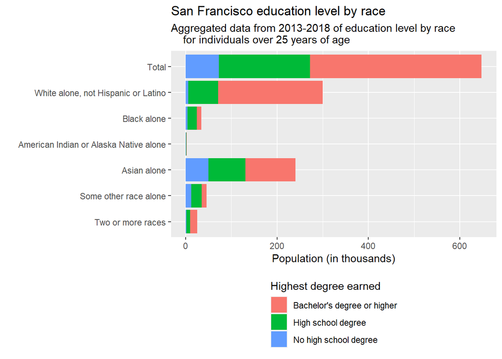

```r
sf_edu_bar_stacked <-
  sf_edu %>%
  ggplot() +
  geom_bar(
    aes(
      x = race %>% factor(
        c(rev(census_race_labels),"Total")),
      y = estimate/1000,
      fill = `Highest degree earned`
    ),
    stat = "identity",
    position = "stack"
  ) +
  labs(
    x = "",
    y = "Population (in thousands)",
    title = "San Francisco education level by race",
    subtitle = "Aggregated data from 2013-2018 of education level by race
    for individuals over 25 years of age",
    fill = "Highest degree earned"
  ) +
  coord_flip() +
  theme(
    legend.position = "bottom",
    legend.direction = "vertical"
  )

sf_edu_bar_stacked
```

The above table shows the total number of people in San Francisco of each race and education level. White and Asian individuals make up the majority of the population. 229,348 white people have bachelor’s degrees or higher, more than the number for all other racial groups combined (146,407).

Next let’s look at the fraction of populations in order to more easily compare education levels across races.

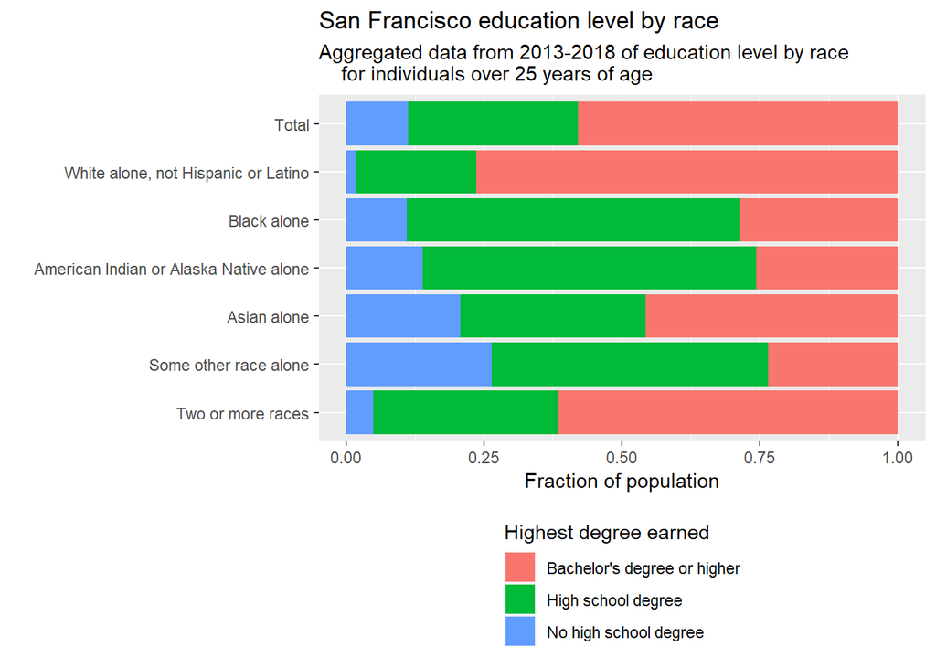

```r
sf_edu_bar_filled <-
  sf_edu %>%
  ggplot() +
  geom_bar(
    aes(
      x = race %>% factor(
        c(rev(census_race_labels),"Total")),
      y = estimate,
      fill = `Highest degree earned`
    ),
    stat = "identity",
    position = "fill"
  ) +
  labs(
    x = "",
    y = "Fraction of population",
    title = "San Francisco education level by race",
    subtitle = "Aggregated data from 2013-2018 of education level by race
    for individuals over 25 years of age",
    fill = "Highest degree earned"
  ) +
  coord_flip() +
  theme(
    legend.position = "bottom",
    legend.direction = "vertical"
  )

sf_edu_bar_filled
```

From the bar chart above, it is apparent that white people in San Francisco have the highest education on average. About 75% of them have bachelor’s degrees or higher, and nearly all have at least a high school degree. By comparison, only 29% of black people in SF have college degrees or higher. The populations with the lowest percentage of bachelor’s degrees were American Indian/Alaska Native and other races (not black, asian or American Indian). This speaks clearly to the racial inequities in education and their work force opportunities.

Looking at this data, I’m curious how long the people surveyed have lived in the Bay Area. San Francisco has become a major destination for young tech workers from all over the country and the world. I would assume that most of these incoming people have at least bachelor’s degrees. So is the racial disparity in education levels a product of disparities in education opportunities for young residents in the city, or does it point to racial bias in Bay Area tech hiring? I would guess it’s a little bit of both.

To start to get at the question of who is coming in and out of the city, we can look at migration data from the most recent ACS surveys.

```r
acs_vars_2019_1yr <-  listCensusMetadata(
    name = "2019/acs/acs1",
    type = "variables"
  )

sf_migration_this_year_19 <-
  getCensus(
    name = "acs/acs1",
    vintage = 2019,
    region = "county:075",
    regionin = "state:06",
    vars = "group(B07009)"
  ) %>%
  select(!c(state,county,GEO_ID,NAME) & !ends_with(c("MA","EA","M"))) %>%
  pivot_longer(
    ends_with("E"),
    names_to = "vars",
    values_to = "estimate"
  ) %>%
  left_join(
    acs_vars_2019_1yr %>%
      select(name,label),
    by = c("vars" = "name")
  ) %>%
  select(-vars) %>%
  separate(
    label,
    into = c(NA,NA,"mobility","education"),
    sep = "!!"
  ) %>%
  filter(!is.na(education)) %>%
  mutate(
    mobility = ifelse(
      mobility %in% c("Same house 1 year ago:","Moved within same county:"),
      "Here since last year",
      "Inflow"
    )
  ) %>%
  group_by(mobility,education) %>%
  summarize(
    estimate = sum(estimate)
  )

sf_migration_last_year_19 <-
  getCensus(
    name = "acs/acs1",
    vintage = 2019,
    region = "county:075",
    regionin = "state:06",
    vars = "group(B07409)"
  ) %>%
  select(!c(state,county,GEO_ID,NAME) & !ends_with(c("MA","EA","M"))) %>%
  pivot_longer(
    ends_with("E"),
    names_to = "vars",
    values_to = "estimate"
  ) %>%
  left_join(
    acs_vars_2019_1yr %>%
      select(name,label),
    by = c("vars" = "name")
  ) %>%
  select(-vars) %>%
  separate(
    label,
    into = c(NA,NA,"mobility","education"),
    sep = "!!"
  ) %>%
  filter(!is.na(education)) %>%
  mutate(
    mobility = ifelse(
      mobility %in% c("Same house:","Moved within same county:"),
      "Here since last year",
      "Outflow"
    )
  ) %>%
  group_by(mobility,education) %>%
  summarize(
    estimate = sum(estimate)
  )

sf_migration_this_year_18 <-getCensus(
    name = "acs/acs1",
    vintage = 2018,
    region = "county:075",
    regionin = "state:06",
    vars = "group(B07009)"
  ) %>%
  select(!c(state,county,GEO_ID,NAME) & !ends_with(c("MA","EA","M"))) %>%
  pivot_longer(
    ends_with("E"),
    names_to = "vars",
    values_to = "estimate"
  ) %>%
  left_join(
    acs_vars_2019_1yr %>%
      select(name,label),
    by = c("vars" = "name")
  ) %>%
  select(-vars) %>%
  separate(
    label,
    into = c(NA,NA,"mobility","education"),
    sep = "!!"
  ) %>%
  filter(!is.na(education)) %>%
  mutate(
    mobility = "Here last year"
  ) %>%
  group_by(mobility,education) %>%
  summarize(estimate = sum(estimate))

edu_levels <- c(
  "Less than high school graduate",
  "High school graduate (includes equivalency)",
  "Some college or associate's degree",
  "Bachelor's degree",
  "Graduate or professional degree")

sf_flows_by_edu <-
  rbind(
    sf_migration_this_year_18,
    sf_migration_last_year_19 %>%
      filter(mobility == "Outflow"),
    sf_migration_this_year_19 %>%
      filter(mobility == "Inflow"),
    sf_migration_this_year_19 %>%
      group_by(education) %>%
      summarize(estimate = sum(estimate)) %>%
      mutate(mobility = "Here this year")
  ) %>%
  pivot_wider(
    names_from = mobility,
    values_from = estimate
  ) %>%
  mutate(
    `External Net` = Inflow - Outflow,
    `Internal Net` = `Here this year` - `Here last year`
  ) %>%
  select(
    Education = education,`Internal Net`,`External Net`,`Here last year`,
    `Here this year`,Inflow,Outflow
  )

paged_table(
  sf_flows_by_edu[order(match(sf_flows_by_edu$Education, edu_levels)),])
```

| Education | Internal Net | External Net | Here last year | Here this year | Inflow | Outflow |
| --- | --- | --- | --- | --- | --- | --- |
| Less than high school graduate | 8158 | -2013 | 73381 | 81539 | 1881 | 3894 |
| High school graduate (includes equivalency) | -2571 | 792 | 85850 | 83279 | 4497 | 3705 |
| Some college or associate's degree | -1667 | -2490 | 123004 | 121337 | 4868 | 7358 |
| Bachelor's degree | -7709 | -6881 | 253594 | 245885 | 17749 | 24630 |
| Graduate or professional degree | 2503 | -1435 | 166736 | 169239 | 15052 | 16487 |

Both inflow and outflow for adults (people older than 25 years) with bachelor’s degrees or graduate/professional degrees are much higher than for people with some college or less. 8% of people with college or graduate degrees in the city are people who have moved into SF in the past year. Almost 10% of those with college or graduate degrees who were here a year ago have moved out. This really speaks to the rapid turnover of people in the Bay Area, particularly those in tech and other high education hiring industries. It makes me wonder how much personal stake they have in city life, in its schools, public transit, policing, etc. How would a large turnover of people affect the psyche of the city? It’s interesting looking at the external net numbers that all but high school graduate are negative (if only slightly; e.g. 2% decrease in bachelors and graduate degree holders). Why are people moving out of the city? Let’s take a look at where they’re going.

```r
sf_migration_out_19 <-
  getCensus(
    name = "acs/acs1",
    vintage = 2019,
    region = "county:075",
    regionin = "state:06",
    vars = "group(B07409)"
  ) %>%
  select(!c(state,county,GEO_ID,NAME) & !ends_with(c("MA","EA","M"))) %>%
  pivot_longer(
    ends_with("E"),
    names_to = "vars",
    values_to = "estimate"
  ) %>%
  left_join(
    acs_vars_2019_1yr %>%
      select(name,label),
    by = c("vars" = "name")
  ) %>%
  select(-vars) %>%
  separate(
    label,
    into = c(NA,NA,"mobility","education"),
    sep = "!!"
  ) %>%
  filter(!is.na(education) & mobility %in% c(
    "Moved to different county within same state:",
    "Moved to different state:")) %>%
  select(mobility,education,estimate) %>%
  pivot_wider(
    names_from = mobility,
    values_from = estimate
  ) %>%
  mutate(
    `% Remained in state` = round(
      `Moved to different county within same state:`/
      (`Moved to different county within same state:` +
         `Moved to different state:`)*100)
  )

paged_table(sf_migration_out_19)
```

| education | Moved to different county within same state: | Moved to different state: | % Remained in state |
| --- | --- | --- | --- |
| Less than high school graduate | 3212 | 682 | 82 |
| High school graduate (includes equivalency) | 2419 | 1286 | 65 |
| Some college or associate's degree | 6178 | 1180 | 84 |
| Bachelor's degree | 17094 | 7536 | 69 |
| Graduate or professional degree | 10367 | 6120 | 63 |

The table tells us that 69% and 63% of people with bachelor’s degrees and graduate/professional degrees who have moved out of SF in the past year have moved to another California county. The percent of high school graduates is similar, but more people without high school degrees and with some college degree stay in state. Unfortunately the data is not granular enough to tell us whether they relocated to another county in the Bay Area (perhaps to have a larger home to start a family, for example), or whether they have left the Bay Area completely to find opportunities elsewhere in the state. I wonder if those who moved out that had some college might be moving to attend a state school elsewhere after finishing their time in community college. We are also missing data here for any people who moved abroad, because they would not be counted in the next year’s ACS.

We can also look at where people moving into the Bay Area came from.

```r
sf_migration_in_19 <-
  getCensus(
    name = "acs/acs1",
    vintage = 2019,
    region = "county:075",
    regionin = "state:06",
    vars = "group(B07009)"
  ) %>%
  select(!c(state,county,GEO_ID,NAME) & !ends_with(c("MA","EA","M"))) %>%
  pivot_longer(
    ends_with("E"),
    names_to = "vars",
    values_to = "estimate"
  ) %>%
  left_join(
    acs_vars_2019_1yr %>%
      select(name,label),
    by = c("vars" = "name")
  ) %>%
  select(-vars) %>%
  separate(
    label,
    into = c(NA,NA,"mobility","education"),
    sep = "!!"
  ) %>%
  filter(!is.na(education) & mobility %in% c(
    'Moved from different county within same state:',
    'Moved from different state:','Moved from abroad:')) %>%
  pivot_wider(
    names_from = mobility,
    values_from = estimate
  ) %>%
  transmute(
    education = education,
    `% moved from CA county` = round(
      `Moved from different county within same state:`/
        (`Moved from different county within same state:` +
           `Moved from different state:` + `Moved from abroad:`)*100),
    `% moved from different state` = round(
      `Moved from different state:`/
        (`Moved from different county within same state:` +
           `Moved from different state:` + `Moved from abroad:`)*100),
    `% moved from abroad` = round(`Moved from abroad:`/
        (`Moved from different county within same state:` +
           `Moved from different state:` + `Moved from abroad:`)*100)
  )

paged_table(sf_migration_in_19)
```

| education | % moved from CA county | % moved from different state | % moved from abroad |
| --- | --- | --- | --- |
| Less than high school graduate | 53 | 6 | 41 |
| High school graduate (includes equivalency) | 59 | 16 | 25 |
| Some college or associate's degree | 73 | 21 | 6 |
| Bachelor's degree | 44 | 34 | 22 |
| Graduate or professional degree | 40 | 41 | 19 |

Over 50% of people with some college or less have moved to San Francisco from another CA county. There is also a large group (41%) of people with less than a high school graduate degree who come from abroad. I’m curious about what makes this number so large. It’s unlikely that these are people with H1-B visas; perhaps it includes refugees, undocumented immigrants, and family members of SF residents. People with Bachelor’s degrees and above are more split between origins, with over 1/3 coming from other states and about 1/5 coming from abroad. This likely reflects the effect of white collar recruiters drawing people from other parts of the world to work in Bay Area industries.

Returning to our original table of migration numbers, internal net flows are also relatively small compared to the total population. These take into account residents turning 25 (+ net) and residents dying (- net). They also take into account the educational development of residents. For example, a person who has gained a bachelors degree in the past year would show up as -1 in the category of “Some college or associate’s degree” and a +1 in the category of “Bachelor’s degree.”

Another important consideration with regards to education, particularly given the pandemic, is children’s access to internet. Unfortunately we don’t yet have data for 2020 from the census, but looking at the 2018 survey can give us an idea of numbers. These data come from PUMS and are filtered at the individual level for respondents in grades K-12.

```r
# Locate vars of interest
pums_vars_2018 <-
  pums_variables %>%
  filter(year == 2018, survey == "acs1") %>%
  distinct(var_code,var_label,data_type,level) %>%
  filter(level == "person")

pums_race_labels <-
  pums_variables %>%
  filter(year == 2018, survey == "acs1") %>%
  filter(var_code == "RAC1P") %>%
  select(
    RAC1P = val_min,
    RAC1P_label = val_label
  )

#Get IDs for PUMAs in SF
sf_county <- counties("CA", progress_bar = F) %>%
  filter(NAME == "San Francisco")

ca_pumas <-
  pumas("CA", cb = T, progress_bar = F)

sf_pumas <-
  ca_pumas %>%
  st_centroid() %>%
  .[sf_county, ] %>%
  st_set_geometry(NULL) %>%
  left_join(ca_pumas %>% select(GEOID10)) %>%
  st_as_sf()

#Download data from these PUMAS
sf_pums <- get_pums(
  variables = c(
    "ACCESS", #internet access
    "AGEP",
    "SCHG",
    "RAC1P"
    ),
  state = "CA",
  puma = sf_pumas$PUMACE10,
  survey = "acs1",
  rep_weights = "person",
  year = 2018
) %>%
  select(PUMA,SERIALNO,AGEP,SCHG,ACCESS,RAC1P,PWGTP) %>%
  filter(PWGTP != 0 & SCHG < 13 & ACCESS != "b") %>%
  left_join(pums_race_labels) %>%
  select(-RAC1P)
```

```r
sf_kids_internet <-
  sf_pums %>%
  mutate(
    ACCESS_label = ifelse(
      ACCESS %in% c(1,2),
      "Has internet",
      "Does not have internet"
    )
  ) %>%
  group_by(RAC1P_label,ACCESS_label) %>%
  summarize(
    total = sum(PWGTP)
  ) %>%
  pivot_wider(
    names_from = ACCESS_label,
    values_from = total
  ) %>%
  mutate(
    `Percent without internet` = round(
      `Does not have internet`/(`Does not have internet`+`Has internet`)*100)
  ) %>%
  rename(
    Race = RAC1P_label
  )

sf_kids_internet[is.na(sf_kids_internet)] = 0

sum(sf_kids_internet$`Does not have internet`,na.rm = T)
```

```
## [1] 2943
```

```r
paged_table(sf_kids_internet)
```

| Race | Does not have internet | Has internet | Percent without internet |
| --- | --- | --- | --- |
| Asian alone | 854 | 19974 | 4 |
| Black or African American alone | 713 | 3733 | 16 |
| Native Hawaiian and Other Pacific Islander alone | 0 | 188 | 0 |
| Some Other Race alone | 796 | 9335 | 8 |
| Two or More Races | 0 | 14955 | 0 |
| White alone | 580 | 27776 | 2 |

By our estimates, 2,943 children do not have access to internet in San Francisco county. This corresponds to 2% of the white children, 4% of Asian children, 16% of black children and 8% of children of some other race alone (not including Native Hawaiian or Pacific Islander).

Finally, I’ll expand this analysis to the entire Bay Area.

```r
bay_county_names <-
  c(
    "Alameda",
    "Contra Costa",
    "Marin",
    "Napa",
    "San Francisco",
    "San Mateo",
    "Santa Clara",
    "Solano",
    "Sonoma"
  )

bay_counties <-
  counties("CA", progress_bar = F) %>%
  filter(NAME %in% bay_county_names)

bay_pumas <- ca_pumas %>%
  st_centroid() %>%
  .[bay_counties, ] %>%
  st_set_geometry(NULL) %>%
  left_join(ca_pumas %>% select(GEOID10)) %>%
  st_as_sf()

bay_pums <- get_pums(
  variables = c(
    "ACCESS", #internet access
    "AGEP",
    "SCHG",
    "RAC1P"
    ),
  state = "CA",
  puma = bay_pumas$PUMACE10,
  survey = "acs1",
  rep_weights = "person",
  year = 2018
) %>%
  select(PUMA,SERIALNO,AGEP,SCHG,ACCESS,RAC1P,PWGTP) %>%
  filter(
    PWGTP != 0 & SCHG < 13 & ACCESS != "b"
  ) %>%
  left_join(pums_race_labels) %>%
  select(-RAC1P)
```

```r
bay_internet_map <-
  bay_pums %>%
  filter(ACCESS == 3) %>%
  group_by(PUMA) %>%
  summarise(
    estimate = sum(PWGTP)
  ) %>%
  right_join(
    bay_pumas %>% select(PUMACE10),
    by = c("PUMA"="PUMACE10")
  ) %>%
  replace(
    .,
    is.na(.),
    0
  ) %>%
  st_as_sf()


internet_pal <- colorNumeric(
  palette = "Blues",
  domain = bay_internet_map$estimate
)


leaflet() %>%
  addMapboxTiles(
    style_id = "light-v9",
    username = "mapbox"
  ) %>%
  addPolygons(
    data = bay_internet_map,
    fillColor = ~internet_pal(estimate),
    fillOpacity = 0.75,
    color = "white",
    weight = 0.5,
    label = ~estimate
  ) %>%
  addLegend(
    data = bay_internet_map,
    pal = internet_pal,
    values = ~estimate,
    title = "Number of students without internet"
  )
```

[interactive chart not shown]

```r
sum(bay_internet_map$estimate)
```

```
## [1] 26310
```

In total, I estimate 26,310 children around the Bay Area are without access to internet. The regions with the greatest number of children without internet are south Oakland, southeast San Francisco (including the neighborhood of Hunter’s Point), Santa Rosa, the PUMA that includes Atherton, Menlo Park and East Palo Alto, and downtown San Jose. I know that Oakland, Hunter’s Point and East Palo Alto are all areas that skew lower-class and POC. I am curious whether Santa Rosa sticks out because of the disastrous Tubbs Fire in 2017 that destroyed a lot of homes in the area. Let’s quickly assess equity by comparing the breakdown of all children by race to the breakdown of children without internet by race.

```r
bay_internet_race <-
  bay_pums %>%
  mutate(
    ACCESS_label = ifelse(
      ACCESS %in% c(1,2),
      "Has internet",
      "Does not have internet"
    )
  ) %>%
  group_by(RAC1P_label,ACCESS_label) %>%
  summarize(
    total = sum(PWGTP)
  ) %>%
  pivot_wider(
    names_from = ACCESS_label,
    values_from = total
  ) %>%
  mutate(
    `Percent without internet` = round(
      `Does not have internet`/(`Does not have internet`+`Has internet`)*100)
  ) %>%
  rename(Race = RAC1P_label)


paged_table(bay_internet_race)
```

| Race | Does not have internet | Has internet | Percent without internet |
| --- | --- | --- | --- |
| American Indian alone | 119 | 3085 | 4 |
| American Indian and Alaska Native tribes specified; or American Indian or Alaska Native, not specified and no other races | 323 | 1187 | 21 |
| Asian alone | 2243 | 250496 | 1 |
| Black or African American alone | 2571 | 56723 | 4 |
| Native Hawaiian and Other Pacific Islander alone | 562 | 5487 | 9 |
| Some Other Race alone | 9874 | 152969 | 6 |
| Two or More Races | 2409 | 141715 | 2 |
| White alone | 8209 | 459516 | 2 |

The percentage of black children without internet is double the percentage of white children. The lack of internet access is most worrying among American Indian and Alaska Native children and Native Hawaiian/Pacific Islander Children; 9% of children from both categories have no internet (here I’ve summed the two categories in the table for American Indian and Alaska Native). There are clear racial disparities that persist at this larger scale as well.